# Species and call types

A list of study species, cetacean call types, soundscape events, and anthropogenic events monitored by NEFSC’s PAB. For marine mammal spectrogram images, see NOAA’s [Sounds in the Ocean](https://www.fisheries.noaa.gov/national/science-data/sounds-ocean-mammals#odontocetes-toothed-whales). For more information about each species, see [this page](https://www.fisheries.noaa.gov/find-species). This is a list of call types that are frequently used to detect specific acoustic events from passive acoustic data. It is not meant to be comprehensive of all marine mammal repertoire’s. For more detailed information about species call types, see the linked acoustic event guides.

# Mysticetes (Baleen Whales): Typically below 5 kHz

### [**Minke whale**](https://docs.google.com/document/d/1_ousoPs5N14lc2Q30PRiQJTqco7hJgHyV0UjiVki3t8/edit?tab=t.0)

Scientific name: *Balaenoptera acutorostrata*  
Code: MIWH  
Call types:

- Minke whale pulse train
  - Currently includes all pulse train types: constant/slow-down/speed-up
  - Code: MWPT

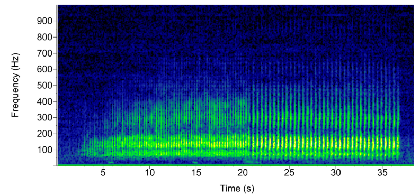

### **Sei whale**

Scientific name: *Balaenoptera borealis*  
Code: SEWH  
Call types:

- Sei whale 30-80 Hz downsweep
  - Sei whale downsweep spanning 80-30Hz, occurs as single downsweeps or repeated 3 - 5 seconds apart as doublets, triplets, or more. If different distinguishable downsweep types are used, please notify PACM group to add call type
  - Code: SWDS

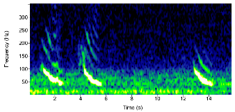

### **Blue whale**

Scientific name: *Balaenoptera musculus*  
Code: BLWH

Call types:

- Blue whale A/B/AB song
  - North Atlantic blue whale song: includes all three call types (A, B, and AB)
  - Code: BLSONG
- Blue whale Arch/D call
  - North Atlantic blue whale Arch calls, or D calls
  - Code: BLARCH

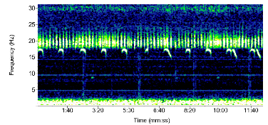

- Blue whale mix calls
  - North Atlantic blue whale mix of calls including A/B/AB song, Arch calls, and D calls
  - Code: BLMIX

### **Fin whale**

Scientific name: *Balaenoptera physalus*  
Code: FIWH  
Call types:

- Fin whale 130-Hz note
  - Fin whale 130-Hz note
  - Code: FWNOTE
- Fin whale 20-Hz pulse
  - Fin whale 20-Hz pulses (song and non-song)
  - Code: FWPLS

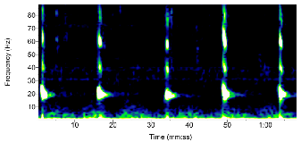

- Fin whale downsweep/ 40-Hz call
  - Fin whale downsweep (termed “higher frequency sounds”, “HF downsweep”, or “40-Hz” call): spanning ~75-40 Hz
  - Code: FWDS
- Fin whale mix calls
  - Mix off North Atlantic fin whale call types: 20-Hz calls, 130-Hz note, and the higher-frequency downsweeps (~75-40 Hz), also referred to as “40-Hz” calls
  - Code: FWMIX

### **North Atlantic right whale**

Scientific name: *Eubalaena glacialis*  
Code: RIWH  
Call types:

- North Atlantic right whale gunshot
  - Right whale gunshot: broadband signal
  - Code: NARWGUNSHOT
- North Atlantic right whale moan
  - Right whale moan: typically 100-200 Hz
  - Code: NARWMOAN
- North Atlantic right whale upcall
  - Contact-call produced by right whales: typically 100-300 Hz upsweep
  - Code: NARWUPCALL

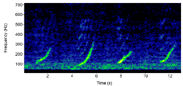

### **Humpback whale**

Scientific name: *Megaptera novaeangliae*  
Code: HUWH  
Call types:

- Humpback whale social
  - Humpback whale social calls only
  - Code: HWSOC
- Humpback whale song
  - Humpback whale song only
  - Code: HWSONG
- Humpback whale mixed call
  - Humpback whale mixed song and social calls
  - Code: HWMIX

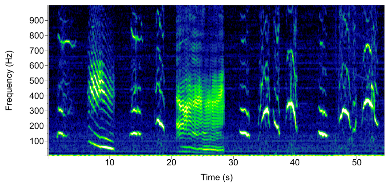

# Odontocetes (Toothed Cetaceans): Typically 10 - 170 kHz

Sources: \\nefscdata\PassiveAcoustics\CONFERENCES_PRESENTATIONS\PRESENTATIONS\TRAININGS\NEFSC_PAB_Intro_Training_2023\2_Applications_of_PAM → PAB_info_session_odontocetes_presentation  
In this section, we organize our odontocete species list by Sperm whale, Delphinidae (broadband, 30-50 kHz peak, and blackfish), Beaked whales, and narrow high-band frequency species (Porpoise, Kogiidae). Each section includes call types, spectra imagery, and wigner plots if applicable. Below is a figure differentiating inter-click-interval ranges of these odontocete groups.

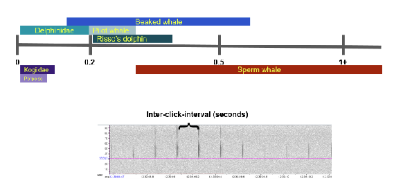

## **Sperm whales**

This section covers all sperm whale calls analyzed by NEFSC passive acoustics branch. A list of sperm whale call types and spectrogram examples are included below.

#### **Sperm whale**

Scientific name: *Physeter macrocephalus*  
Code: SPWH  
Call types:

- Sperm whale coda
  - Sperm whale social: coda
  - Code: SPCODA
- Sperm whale creak
  - Sperm whale terminal foraging buzz
  - Code: SPCREAK
- Sperm whale foraging
  - When there’s a mix of sperm whale foraging call types (i.e. usual clicks and buzzes)
  - Code: SPFORG
- Sperm whale slow click/ clangs
  - Sperm whale social: slow clicks and clangs
  - Code: SPSLCC
- Sperm whale social buzz
  - Sperm whale social: social buzz
  - Code: SPSOCBZ
- Sperm whale social mix
  - When there’s a mix of sperm whale social call types (i.e. codas & social buzzes)
  - Code: SPMIX
- Sperm whale usual click
  - Sperm whale echolocation click
  - Code: SPUSC

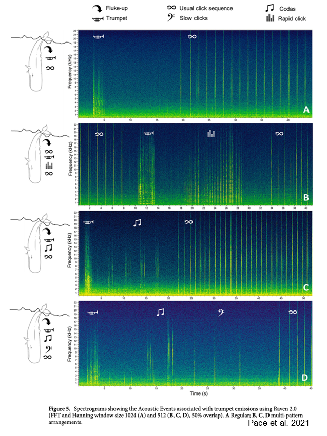

Sperm whale impulsive creak click type

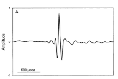

Madsen et al. 2002

## **Dolphins (Broadband, 30- 50 kHz peak, Blackfish)**

Dolphinid and blackfish species produce various clicks and whistles. Dolphinid specie/click pairings are usually ground truthed used visual pairing techniques such as towed arrays. Due to the difficulty of pairing dolphinid species with their clicks, NEFSC PAB groups dolphin call types together using the following list. Whistles are more easily distinguished between species - spectrograms are included under each specie.

Call types across dolphin groups:

- Odontocete buzz
  - Dolphin buzzes
  - Code: ODBZ
- Odontocete impulsive
  - Dolphin clicks
  - Code: ODCLICK
- Odontocete mixed calls
  - When there’s a mix of whistles, clicks, burst pulses, etc. for dolphins
  - Code: ODMIX
- Odontocete whistle
  - Dolphin whistles
  - Code: ODWHIS
- Odontocete burst pulse
  - Dolphin burse pulses
  - Code: ODBP

### *Broadband*

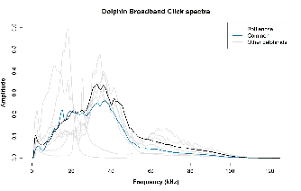

#### **Bottlenose dolphin**

Scientific name: *Turiops truncatus*  
Code: BODO

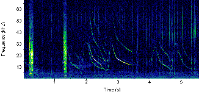

#### **Short beaked Common dolphin**

Scientific name: *Delphinus delphis*  
Code: SADO

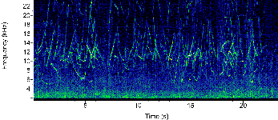

### *30-50 kHz peak*

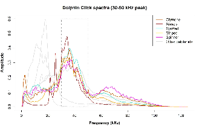

#### **Rissos dolphin**

Scientific name: *Grampus griseus*  
Code: GRAM

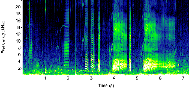

#### **Atlantic spotted dolphin**

Scientific name: *Stenella frontalis*  
Code: WSDO

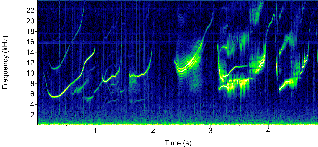

#### **Striped dolphin**

Scientific name: *Stenella coeruleoalba*  
Code: STDO

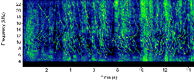

#### **Spinner dolphin**

Scientific name: *Stenella longirostris*  
Code: SNDO

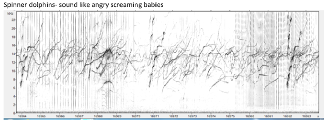

### *Blackfish*

Along with belugas and narwhales, blackfish can biphonate - produce multiple frequencies at once. This is observed in their pulsed calls (example below), and is used in species identification. A click spectra for NEFSC PAB blackfish species is included below.

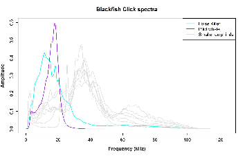

Blackfish biphonate pulse call

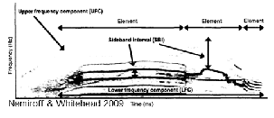

#### **False killer whale**

Scientific name: *Pseudorca crassidens*  
Code: FKWH

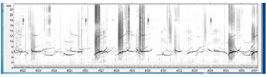

#### **Short finned pilot whale**

Scientific name: *Globicephala macrorhynchus*  
Code: SFPW

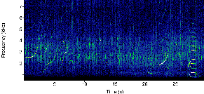

**Globicephala spp.*

## **Beaked Whales**

Call types across beaked whale groups:

- Beaked whale frequency modulated upsweeps
  - Beaked whale foraging clicks
  - Code: BWFMUP
- Beaked whale surface click
  - Beaked whale communication, does not contain frequency-modulation
  - Code: BWCLICK

Beaked whale click spectra plot

Beaked whale frequency modulated click type (and delphinids off-axis)

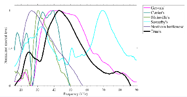

DeAngelis et al. 2018

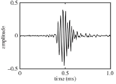

Cholewiak et al. 2017

#### **Sowerby’s beaked whale**

Scientific name: Mesoplodon bidens  
Code: SOBW

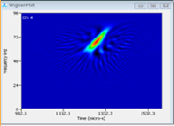

#### **Blainville’s beaked whale**

Scientific name: Mesoplodon densirostris  
Code: BLBW

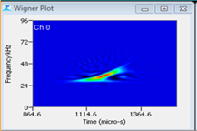

#### **Gervais’ beaked whale**

Scientific name: Mesoplodon europaeus  
Code: GEBW

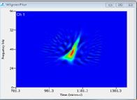

#### **True’s beaked whale**

Scientific name: Mesoplodon mirus  
Code: TRBW

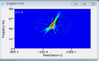

#### **Cuvier’s beaked whale**

Scientific name: *Ziphius cavirostris*  
Code: CUBW

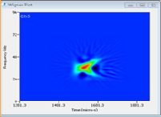

#### **Gulf of Mexico’s Beaked whale (BWG, unknown)**

Scientific name: Ziphiidae sp.  
Code: BWG

#### **Unid True’s/Gervais beaked whale**

Scientific name: Mesoplodon mirus/europaeus  
Code: MMME

## **Narrow high-band frequency**

Narrow high-band frequency species include porpoises and Kogiidae species (Pygmy and Dwarf sperm whales). Both groups produce indifferentiable clicks (shown in Wigner plot). Clicks are differentiated by recording location - nearshore narrow high-band frequency clicks are denoted as porpoise clicks, offshore as Kogiidae clicks (map below). Porpoises also produce buzzes.

Call types across high-band frequency group:

- Narrow band high frequency click
  - Narrow band high frequency clicks used by kogia and porpoises
  - Code: NBHF

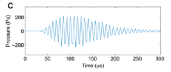

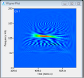

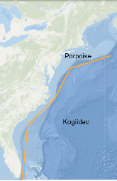

Malinka et al. 2021

#### **Harbor porpoise**

Scientific name: *Phocoena phocoena*  
Code: HAPO  
Call types:

- Porpoise buzz
  - Buzzes used by porpoise species, either social or foraging
  - Code: POBZ

#### **Pygmy sperm whale**

Scientific name: *Kogia breviceps*  
Code: PSWH

#### **Dwarf sperm whale**

Scientific name: *Kogia sima*  
Code: DSWH